# Example of processing FT-ICR data

*Marc-André Delsuc - Joensuu August 2018*

First load some libraries

```python
from __future__ import print_function, division
import array
import os.path as op
import numpy as np

import matplotlib as mpl
import matplotlib.pylab as plt
%matplotlib inline
```

locate the data-set which should be in the repository

```python
ls files/FTICR-Files/080617-insulin_2M_MS_000001.d
```

```
Wesley_nanoLCMS04042012.m/ analysis.baf_xtr*
analysis.baf*              desktop.ini*
analysis.baf_idx*          fid*
```

so now we can read it

```python
BASE = 'files/FTICR-Files/ESI_pos_Ubiquitin_000006.d'
```

```python
F = open(  op.join(BASE, 'fid'), 'rb')
tbuf = F.read()
fid = np.array(array.array('i',tbuf))
F.close()
```

```python
len(fid)
```

```
4194304
```

```python
fid[1000:1010]
```

```
array([ 1137,   125,  1623,   952,  -138,  -366,  -857, -1464, -1604,
       -1247], dtype=int32)
```

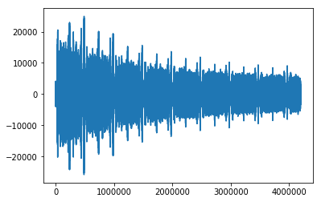

```python
plt.plot(fid)
```

### Fourier processing

*small complication*

There are 2 fft packages available

- `numpy.fft`
  - simple, basic, efficient
- `scipy.fftpack`
  - slightly faster, more complex

we are going to use `numpy.fft`

```python
sp = np.fft.fft(fid)
```

```python
print (sp[10])
len(sp)
```

```
(-70742.64832249525+217578.94774257578j)
```

```
4194304
```

```python
# default size of the figures
mpl.rcParams['figure.figsize'] = [10.0,8.0]
# this helps matplotlib to draw the huge vectors we're using (4-8Mpoints)
mpl.rcParams['agg.path.chunksize'] = 100000
```

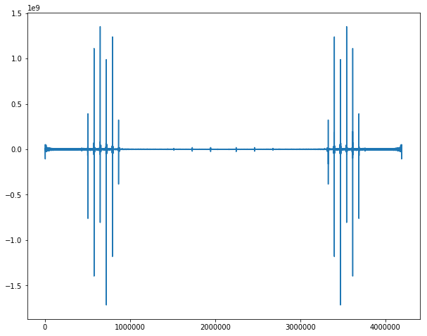

```python
plt.plot(sp)
```

3 remarks

- imaginary discarded (eventually silently)
- phase
- symetry

1 syntax remark

```python
from numpy.fft import fft, rfft
sp = rfft(fid)
print (sp[0])
len(sp)
```

```
(-2681443+0j)
```

```
2097153
```

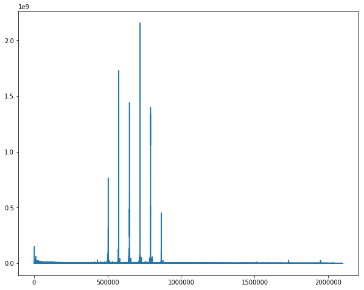

```python
plt.plot(abs(sp))     # absolute value is modulus
```

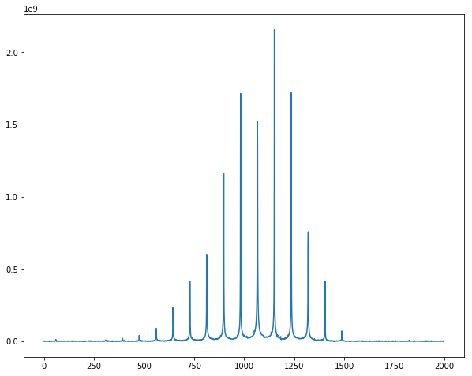

```python
# let's zoom in
plt.plot(abs(sp[720000:722000]))
```

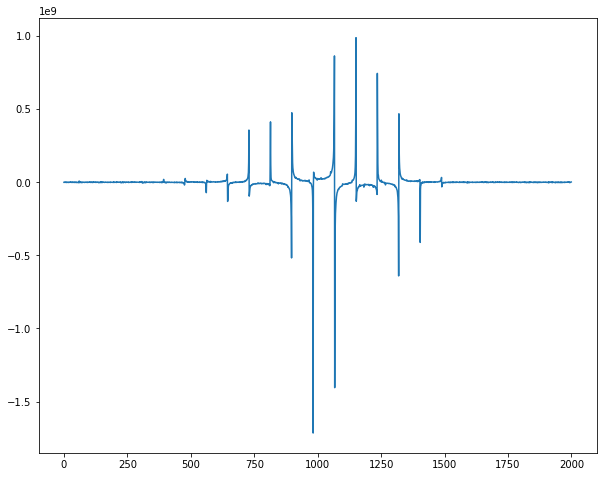

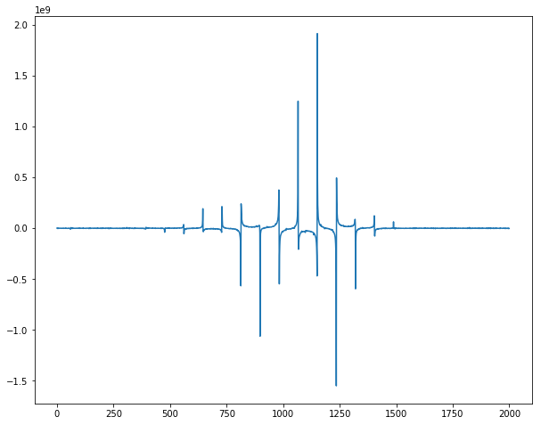

```python
# without the abs() we see the phase rotating
plt.plot(sp[720000:722000])
plt.figure()
# we rotate by 90° the phase
plt.plot(1j*sp[720000:722000])
```

## 2 possible improvements

- improved resolution by apodisation
- recovery of the full resolution by zerofilling

  ### apodisation

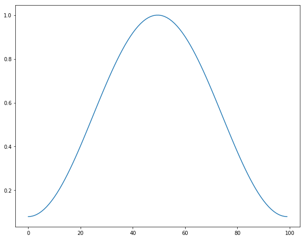

```python
plt.plot(np.hamming(100))
```

there is also `blackman` `hanning` `bartlett`...

```python
sp2 = rfft( np.hamming(len(fid))*fid )
```

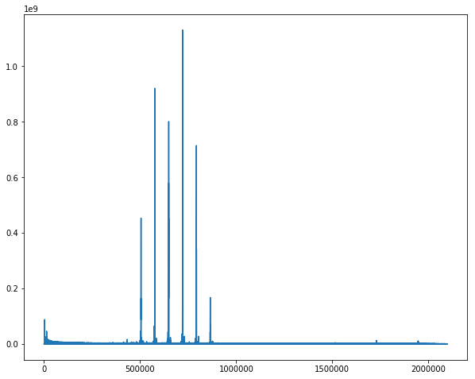

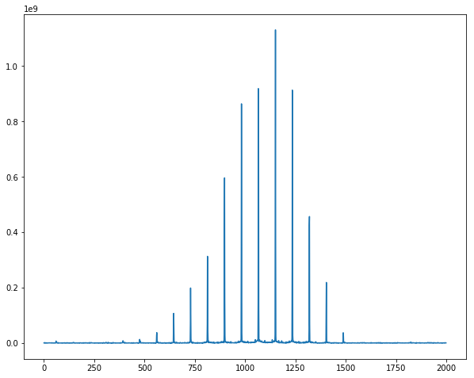

```python
plt.plot(abs(sp2))
plt.figure()
plt.plot(abs(sp2[720000:722000]))
```

Notice how lineshape is improved, and the isotopic pattern intensities restored

We can superimpose both processing, zooming on a line you can see that FWHM is sligthly worse when apodized.

Theory is 1.5 for hamming window, but does not really show here.

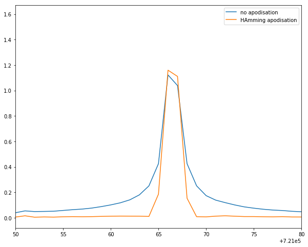

```python
plt.plot(abs(sp)/max(sp), label="no apodisation")
plt.plot(abs(sp2)/max(sp2), label="HAmming apodisation")
plt.xlim(721050,721080)
plt.legend()
```

### zerofilling

zerofilling consists in adding zero at the end of the FID to interpolate points in the spectrum and smooth the result

( and an example of slighlty different numpy arithmetics)

```python
n = len(fid)
fidzf = np.zeros(2*n)
```

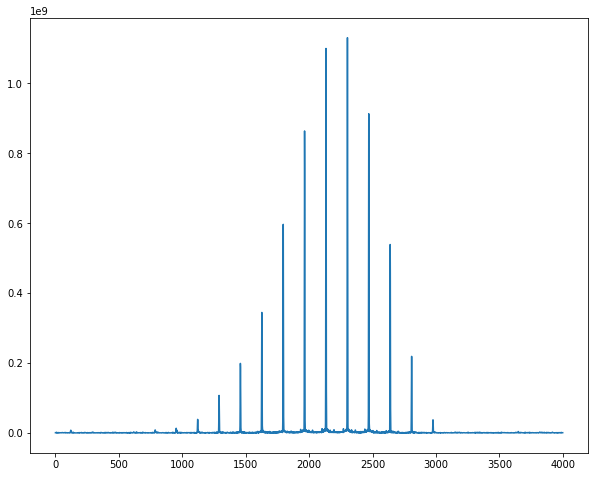

```python
fidzf[:n] = fid[:]
fidzf[:n] *= np.hamming(n)
spzf = abs(rfft( fidzf ))
plt.plot(abs(spzf[2*720000:2*722000]))
```

lineshape and isotopic pattern intensities further improved !

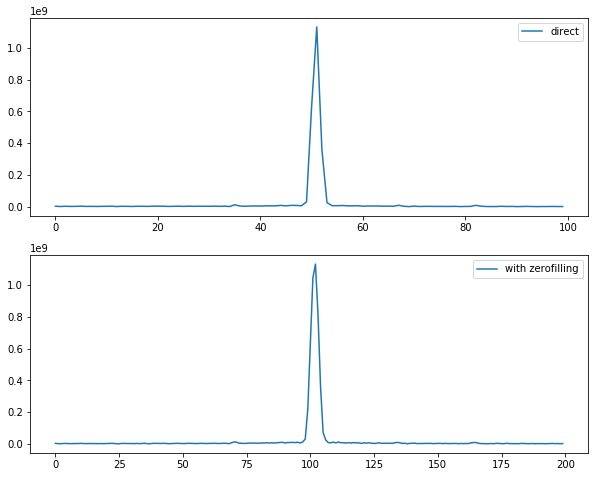

```python
plt.subplot(211)
plt.plot(abs(sp2[721100:721200]), label='direct')
plt.legend()
plt.subplot(212)
plt.plot(abs(spzf[2*721100:2*721200]), label='with zerofilling')
plt.legend()
```

# m/z Calibration

In FT-ICR, the frequency $f$ depends on the magnetic field $B_o$ the charge $z$ and the mass $m$ : $$ f = \frac{B_o z}{m} \quad \Rightarrow \quad m/z = \frac{B_o}{f}$$ We are going to use a sligthly extended equation which takes cares of experimental imperfections: $$ m/z = \frac{M_1}{M_2+f}$$ where $M_1$ and $M_2$ are constants determined precisely by a calibration procedure

### parameter files

FT-ICR parameters are stored in the .method files

```python
ls 'files/FTICR-Files/ESI_pos_Ubiquitin_000006.d/ESI_pos_150_3000.m/apexAcquisition.method'
```

```
files/FTICR-Files/ESI_pos_Ubiquitin_000006.d/ESI_pos_150_3000.m/apexAcquisition.method*
```

```python
cat 'files/FTICR-Files/ESI_pos_Ubiquitin_000006.d/ESI_pos_150_3000.m/apexAcquisition.method'
```

```
</method>
```

# utility

parameter are stored in a XML file, we can look through the file and get the parameters manually, but it is also possible to simply build a dictionary from the entries.

Here a simple mini parser, using standard python library

```python
from xml.dom import minidom
def read_param(filename):
    """
        Open the given file and retrieve all parameters from apexAcquisition.method
        NC is written when no value for value is found

        structure : <param name = "AMS_ActiveExclusion"><value>0</value></param>

        read_param returns  values in a dictionnary
    """
    xmldoc = minidom.parse(filename)

    x = xmldoc.documentElement
    pp = {}
    children = x.childNodes
    for child in children:
        if (child.nodeName == 'paramlist'):
            params = child.childNodes
            for param in params:
                if (param.nodeName == 'param'):
                    k = str(param.getAttribute('name'))
                    for element in param.childNodes:
                       if element.nodeName == "value":
                           try:
                               v = str(element.firstChild.toxml())
                               #print v
                           except:
                               v = "NC"
                    pp[k] = v
    return pp
```

```python
pfile = op.join(BASE, 'ESI_pos_150_3000.m', 'apexAcquisition.method')
param = read_param(pfile)
print (param['TD'])
```

```
4194304
```

```python
# print the 10 first entries
len(list(param.keys()))
```

```
781
```

```python
param['ML1']
```

```
'1.8427001783361462E8'
```

```python
# we find the parameters in the parameter file
sw = float(param['SW_h_Broadband'])
ml1 = float(param['ML1'])
ml2 = float(param['ML2'])
print('Spectral width: {}'.format(sw) )
print('constant M_1: {}'.format(ml1))
print('constant M_2: {}'.format(ml2))
```

```
Spectral width: 625000.0
constant M_1: 184270017.83361462
constant M_2: 5.039161102310875
```

```python
faxis = np.linspace(0, sw, len(spzf))    # the freq axis from 0 to sw
```

```python
mzaxis = ml1/(ml2+faxis)    # and the mzaxis
```

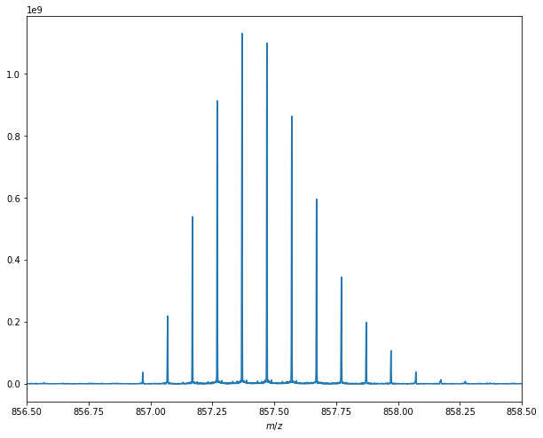

```python
plt.plot(mzaxis, spzf)
plt.xlim(856.5, 858.5)
plt.xlabel("$m/z$");
```

we can zoom on the monoisotopic peak, and try to determine precisely its value.

We know the theorical mass is 856.969496 (for the $z=10$ state).

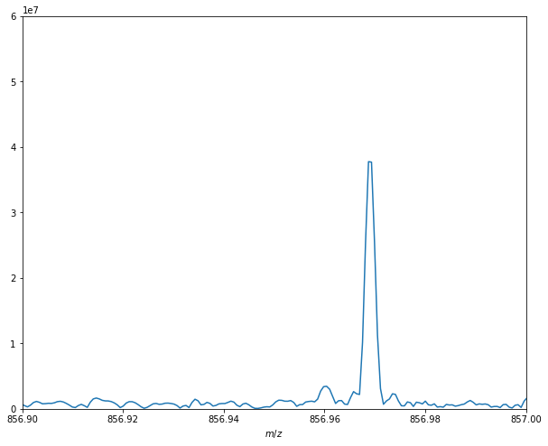

```python
plt.plot(mzaxis, spzf)
plt.xlim(856.9, 857.0)
plt.ylim(0,6E7)
plt.xlabel("$m/z$");
```

```python
# these functions convert back and forth from index to m/z
def itomz(val, N):
    """transform index to m/z for N points,
    using current ml1 ml2 and sw
    """
    f = sw*val/N
    return ml1/(ml2+f)
def mztoi(m, N):
    """transform m/z to index for N points,
    using current ml1 ml2 and sw
    """
    f = ml1/m - ml2
    return N*f/sw
theo = 856.9694962104804
def ppm(theorical, measured):
    return 1E6*(measured-theorical)/measured
```

we can compute the vector coordinates of the previous zoom window

```
start: 1442924  - end: 1443093
maximum is at: 1442977, for m/z: 856.9689406761887
For an error of -0.648 ppm
```

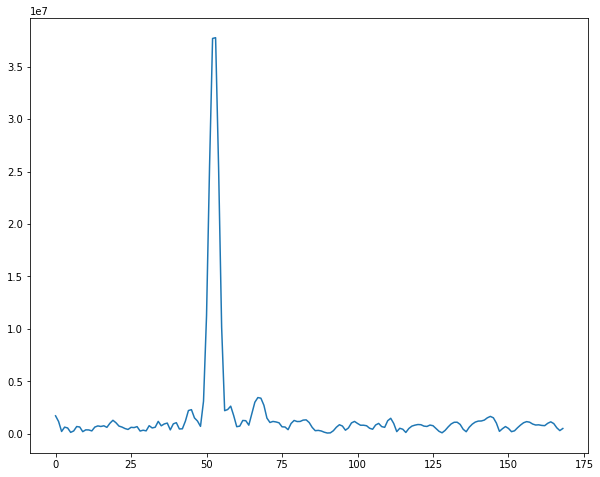

```python
start = int( mztoi(857.0, len(spzf)))
end = int( mztoi(856.9, len(spzf)))
print("start: {}  - end: {}".format(start,end))
plt.plot(spzf[start:end])
top = spzf[start:end].argmax() + start
meas1 = itomz(top,len(spzf))
print("maximum is at: {}, for m/z: {}".format(top,meas1))
print("For an error of {:.3f} ppm".format(ppm(theo, meas1)))
```

```python
# peak barycenter
bary = 0.0
s = 0
for i in range(-3, +4):
    bary += i*spzf[i+top]
    s += spzf[i+top]
mbary = itomz(bary/s+top, len(spzf))
print ("peak barycenter is at {}".format(mbary))
print("For an error of {:.3f} ppm".format(ppm(theo, mbary)))
```

```
peak barycenter is at 856.9692194653925
For an error of -0.323 ppm
```

# packing it up

Now we can simply build a function doing all this at once :

```python
import glob
def read_fticr(folder):
    """
    load and process the data Solarix Apex FTICR file found in folder
    uses the calibration from the parameter file

    eg:
    spectrum,axis = read_fticr('FTICR/Files/bruker ubiquitin file/ESI_pos_Ubiquitin_000006.d')
    """
    # find and load parameters
    L = glob.glob(op.join(folder,"*","apexAcquisition.method"))
    if len(L)>1:
        raise Exception( "You have more than 1 apexAcquisition.method file in the %s folder, using the first one"%folder )
    elif len(L) == 0:
        raise Exception( "You don't have any apexAcquisition.method file in the  %s folder, please double check the path"%folder )
    param = read_param(L[0])

    # load data
    n = int(param['TD'])
    fidzf = np.zeros(2*n)
    with  open(  op.join(BASE, 'fid'), 'rb') as F:  # 'with' a better way of reading a file
        tbuf = F.read(4*int(param['TD']))
        fidzf[:n] = np.array(array.array('i',tbuf)) # [:] is less memory intensive

    # process
    fidzf[:n] *= np.hamming(n)
    spectrum = abs( rfft( fidzf ) )

    # calibrate
    sw = float(param['SW_h_Broadband'])
    ml1 = float(param['ML1'])
    ml2 = float(param['ML2'])
    faxis = np.linspace(0, sw, len(spectrum))    # the freq axis from 0 to sw
    mzaxis = ml1/(ml2+faxis)    # and the mzaxis
    return spectrum, mzaxis
```

```python
spectrum,axis = read_fticr('files/FTICR-Files/ESI_pos_Ubiquitin_000006.d')
```

[output not shown]

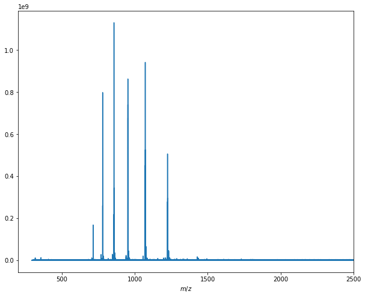

```python
# %matplotlib
plt.plot(axis, spectrum)
plt.xlabel("$m/z$")
plt.xlim(200,2500)
```

[output not shown]

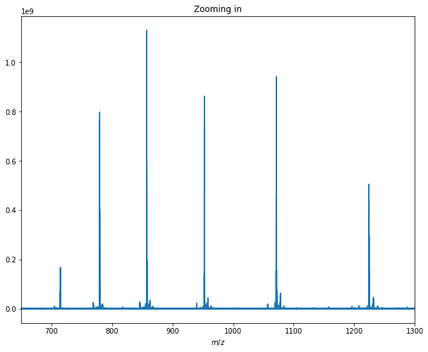

```python
plt.plot(axis, spectrum)
plt.xlabel("$m/z$")
plt.xlim(650,1300)
plt.title("Zooming in")
```

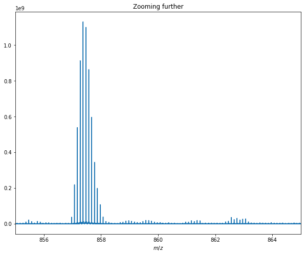

```python
plt.plot(axis, spectrum)
plt.xlabel("$m/z$")
plt.xlim(855,865)
plt.title("Zooming further");
```

# Doing the same thing with SPIKE

SPIKE is a complete software suite we're building to do this, *and much more*

It is distributed here : https://bitbucket.org/delsuc/spike

However, the program is still in development, stay tuned !

```python
import sys
sys.path.append('/Users/mad/')  # adapt this to your own set-up
import spike
from spike.File import Apex
```

[output not shown]

```python
File = 'files/FTICR-Files/080617-insulin_2M_MS_000001.d'
dd = Apex.Import_1D(File)
```

```
1D data-set
Axis F1 :FT-ICR report axis at 769.230769 kHz,  2097152 real points,  from physical mz =  187.692   to m/z = 5000.000  R max (M=400) = 984074
data-set is real
```

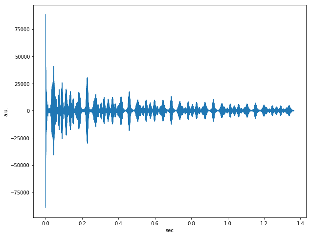

```python
dd.unit = "sec"
dd.display()
```

```
1D data-set
Axis F1 :FT-ICR report axis at 769.230769 kHz,  4194304 real points,  from physical mz =  187.692   to m/z = 5000.000  R max (M=400) = 1968148
data-set is real
```

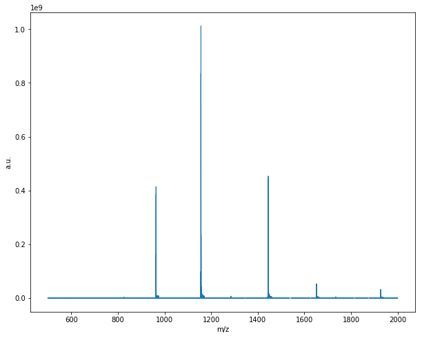

```python
dd.hamming().zf(4).rfft().modulus()
dd.unit = "m/z"
dd.display(zoom=(500,2000))
```

```python
dd.pp(threshold=1E7)
print ("detected %d peaks"%len(dd.peaks))
```

```
PP Threshold: 10000000.0
detected 146 peaks
```

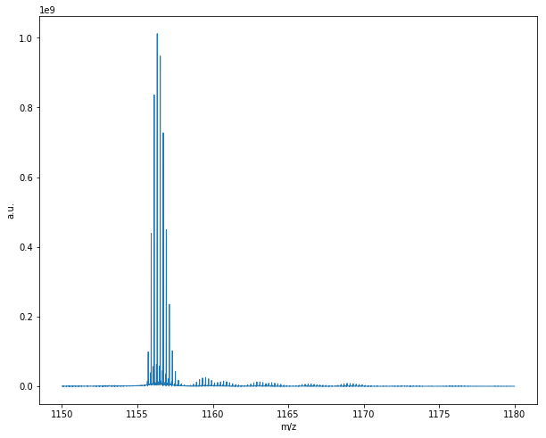

```python
dd.display(zoom=(1150,1180))
dd.display_peaks(zoom=(856.5, 858.5))
```

```python
p = dd.peaks[40]
```

```python
p.report()
```

```
'40, 40, 544737.00, 340973582.28'
```

```python
p.label = "Peak 40"
p.report()  # in index
p.report(f=dd.axis1.itomz)  # provides in m/z
# string is :
# id, label, m/z, intensity, width (0 if not determined)
```

```
'40, Peak 40, 1444.89, 340973582.28'
```

```python
dd.centroid()
for p in dd.peaks:
    p.label = "%.5f"%(dd.axis1.itomz(p.pos))
```

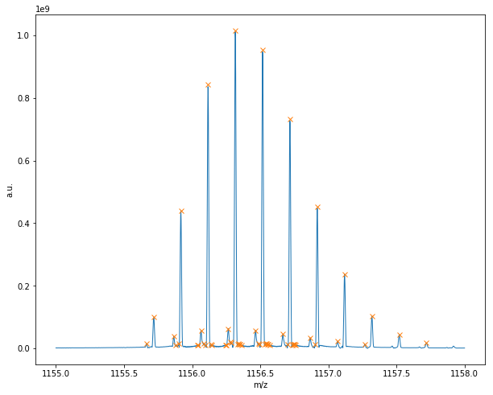

```python
# this switches to a different display mode
z = (1155,1158)
dd.display(zoom=z)
dd.display_peaks(zoom=z) #, peak_label=True)
```

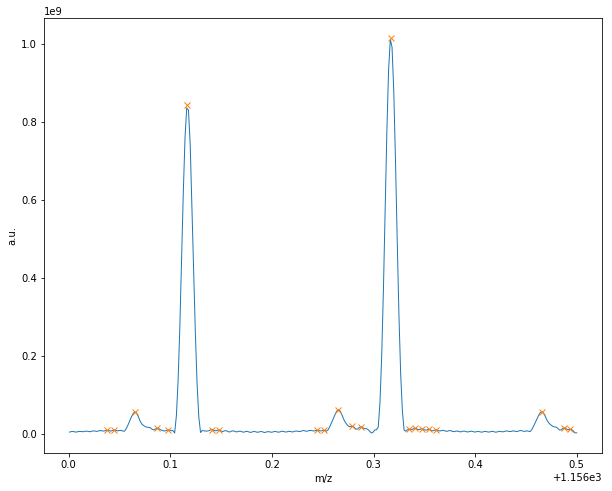

```python
# this switches to a different display mode
z = (1156,1156.5)
dd.display(zoom=z)
dd.display_peaks(zoom=z) #, peak_label=True)
```